# WiDS_Datathon_2022

Uyen Nguyen

2/21/2022

### EDA

```r
# Making two vectors to contain column names of train dataset and how many NAs
# there are for each column

na_col <- c()
col_names <- colnames(train)

for (i in 1:ncol(train)) {
  na_col[i] <- sum(is.na(train[,i]))
}

tibble(col_names, na_col) %>%
  filter(na_col != 0) %>%
  arrange(desc(na_col))
```

```
## # A tibble: 6 x 2
##   col_names                 na_col
##   <chr>                      <int>
## 1 days_with_fog              45796
## 2 direction_peak_wind_speed  41811
## 3 direction_max_wind_speed   41082
## 4 max_wind_speed             41082
## 5 energy_star_rating         26709
## 6 year_built                  1837
```

The variables:

- days_with_fog
- direction_peak_wind_speed
- direction_max_wind_speed
- max_wind_speed

all have NAs for more than half of the rows in train. While

- energy_star_rating
- year_built

have NAs for less than half of the rows in train. There are **11309 (less than a quarter)** complete cases in train. This might be something to keep in mind regarding the approach we will take.

Since we’re not entirely sure if we’ll be using the train dataset that includes NAs in several columns or we’ll be using only the completed cases instead. I created the train_complete_cases tibble with only complete cases free from columns’ NAs mentioned above.

(If we decide to use train_complete_cases to fit our model, we should also bootstrap our training tibble since we took a massive cut to the data set.)

```r
train_complete_cases <- train[complete.cases(train),]
summary(train_complete_cases)
```

```
##   Year_Factor   State_Factor       building_class     facility_type
##  Min.   :1.00   Length:11309       Length:11309       Length:11309
##  1st Qu.:3.00   Class :character   Class :character   Class :character
##  Median :5.00   Mode  :character   Mode  :character   Mode  :character
##  Mean   :4.24
##  3rd Qu.:5.00
##  Max.   :6.00
##    floor_area        year_built   energy_star_rating   ELEVATION
##  Min.   :   8019   Min.   :   0   Min.   :  0.00     Min.   :  1.8
##  1st Qu.:  66832   1st Qu.:1927   1st Qu.: 39.00     1st Qu.:  3.4
##  Median :  98352   Median :1951   Median : 66.00     Median : 25.6
##  Mean   : 173983   Mean   :1950   Mean   : 60.27     Mean   : 26.0
##  3rd Qu.: 172590   3rd Qu.:1971   3rd Qu.: 84.00     3rd Qu.: 42.7
##  Max.   :3636683   Max.   :2015   Max.   :100.00     Max.   :201.8
##  january_min_temp january_avg_temp january_max_temp february_min_temp
##  Min.   :-9.000   Min.   :20.40    Min.   :44.00    Min.   :-13.000
##  1st Qu.: 6.000   1st Qu.:29.68    1st Qu.:56.00    1st Qu.:  2.000
##  Median : 8.000   Median :29.85    Median :56.00    Median :  2.000
##  Mean   : 9.041   Mean   :32.03    Mean   :57.74    Mean   :  8.269
##  3rd Qu.:11.000   3rd Qu.:34.45    3rd Qu.:59.00    3rd Qu.: 15.000
##  Max.   :41.000   Max.   :55.10    Max.   :77.00    Max.   : 42.000
##  february_avg_temp february_max_temp march_min_temp  march_avg_temp
##  Min.   :13.55     Min.   :38.00     Min.   :-9.00   Min.   :29.15
##  1st Qu.:23.95     1st Qu.:43.00     1st Qu.:12.00   1st Qu.:38.10
##  Median :31.62     Median :56.00     Median :13.00   Median :38.10
##  Mean   :32.04     Mean   :55.07     Mean   :18.12   Mean   :42.16
##  3rd Qu.:37.71     3rd Qu.:62.00     3rd Qu.:25.00   3rd Qu.:48.87
##  Max.   :56.80     Max.   :78.00     Max.   :47.00   Max.   :61.44
##  march_max_temp  april_min_temp  april_avg_temp  april_max_temp  may_min_temp
##  Min.   :54.00   Min.   :18.00   Min.   :45.18   Min.   :70     Min.   :33.00
##  1st Qu.:62.00   1st Qu.:31.00   1st Qu.:53.33   1st Qu.:80     1st Qu.:43.00
##  Median :66.00   Median :32.00   Median :54.25   Median :81     Median :48.00
##  Mean   :69.29   Mean   :31.46   Mean   :53.78   Mean   :82     Mean   :45.61
##  3rd Qu.:77.00   3rd Qu.:35.00   3rd Qu.:54.30   3rd Qu.:83     3rd Qu.:48.00
##  Max.   :85.00   Max.   :47.00   Max.   :61.02   Max.   :91     Max.   :51.00
##   may_avg_temp    may_max_temp   june_min_temp   june_avg_temp
##  Min.   :52.15   Min.   :79.00   Min.   :40.00   Min.   :56.23
##  1st Qu.:62.79   1st Qu.:88.00   1st Qu.:50.00   1st Qu.:71.18
##  Median :64.48   Median :88.00   Median :50.00   Median :71.18
##  Mean   :65.04   Mean   :88.81   Mean   :51.03   Mean   :71.17
```

[output cut: 57 more lines]

```
##  Max.   :21.0000   Max.   :136.00   Max.   :52.00   Max.   :10.0000
##  days_above_110F direction_max_wind_speed direction_peak_wind_speed
##  Min.   :0       Min.   :  1              Min.   :  1.0
##  1st Qu.:0       1st Qu.:  1              1st Qu.:  1.0
##  Median :0       Median :  1              Median :  1.0
##  Mean   :0       Mean   :136              Mean   :138.6
##  3rd Qu.:0       3rd Qu.:330              3rd Qu.:340.0
##  Max.   :0       Max.   :360              Max.   :360.0
##  max_wind_speed   days_with_fog      site_eui            id
##  Min.   : 1.000   Min.   : 12.0   Min.   :  1.30   Min.   :  404
##  1st Qu.: 1.000   1st Qu.: 65.0   1st Qu.: 60.01   1st Qu.:22261
##  Median : 1.000   Median :106.0   Median : 78.53   Median :45080
##  Mean   : 7.482   Mean   :104.3   Mean   : 86.09   Mean   :40873
##  3rd Qu.:17.000   3rd Qu.:148.0   3rd Qu.: 99.83   3rd Qu.:52447
##  Max.   :23.300   Max.   :261.0   Max.   :916.91   Max.   :73148
```

After gathering only the complete cases, I noticed that days_above_110F had 0 for both min and max so I took that column out.

```r
train_complete_cases <- train_complete_cases %>% select(-days_above_110F)
```

The correlation matrix is produced below.

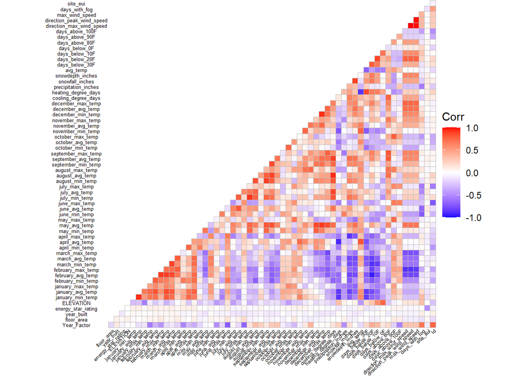

```r
ggcorrplot(cor(train_complete_cases %>% select(where(is.numeric))), type = 'lower', tl.cex = 5, ggtheme = ggplot2::theme_void())
```

There are no real variables that jumped out for the response variable site_eui from the correlation matrix so we’ll proceed with caution on any linear assumptions.

For the sake of visualization, I grouped values in the variable facility_type into broader categories such as Public, Education, Healthcare, etc. to better visualize these groups.

```r
# Making a function to convert details in facility_type into broad groups in
# variable class
train_complete_cases$class <- ''

train_complete_cases[train_complete_cases$facility_type %in% c('2to4_Unit_Building', '5plus_Unit_Building',
                                 'Mixed_Use_Commercial_and_Residential',
                                 'Mixed_Use_Predominantly_Commercial',
                                 'Mixed_Use_Predominantly_Residential',
                                 'Multifamily_Uncategorized'),]$class <- 'Residential'
train_complete_cases[str_which(train_complete_cases$facility_type, 'Public'),]$class <- 'Public'
train_complete_cases[str_which(train_complete_cases$facility_type, 'Education'),]$class <- 'Education'
train_complete_cases[str_which(train_complete_cases$facility_type, 'Food Service'),]$class <- 'Food Service'
train_complete_cases[str_which(train_complete_cases$facility_type, 'Food'),]$class <- 'Food Service'
train_complete_cases[str_which(train_complete_cases$facility_type, 'Health'),]$class <- 'Health Care'
train_complete_cases[str_which(train_complete_cases$facility_type, 'Office'),]$class <- 'Office'
train_complete_cases[str_which(train_complete_cases$facility_type, 'Lodging'),]$class <- 'Lodging'
train_complete_cases[str_which(train_complete_cases$facility_type, 'Nursing'),]$class <- 'Health Care'
train_complete_cases[str_which(train_complete_cases$facility_type, 'Retail'),]$class <- 'Retail'
train_complete_cases[str_which(train_complete_cases$facility_type, 'Warehouse'),]$class <- 'Warehouse'
train_complete_cases[str_which(train_complete_cases$facility_type, 'Service'),]$class <- 'Service'
train_complete_cases[str_which(train_complete_cases$facility_type, 'Religious'),]$class <- 'Religious'
train_complete_cases[str_which(train_complete_cases$facility_type, 'Industrial'),]$class <- 'Industrial'
train_complete_cases[str_which(train_complete_cases$facility_type, 'Laboratory'),]$class <- 'Health Care'
train_complete_cases[str_which(train_complete_cases$facility_type, 'Commercial'),]$class <- 'Commercial'
train_complete_cases[str_which(train_complete_cases$facility_type, 'Data'),]$class <- 'Data Center'
train_complete_cases[str_which(train_complete_cases$facility_type, 'Grocery'),]$class <- 'Grocery'
train_complete_cases[str_which(train_complete_cases$facility_type, 'Parking'),]$class <- 'Parking Garage'
train_complete_cases[str_which(train_complete_cases$facility_type, 'Religious'),]$class <- 'Religious'
```

Here are some plots to visualize this data.

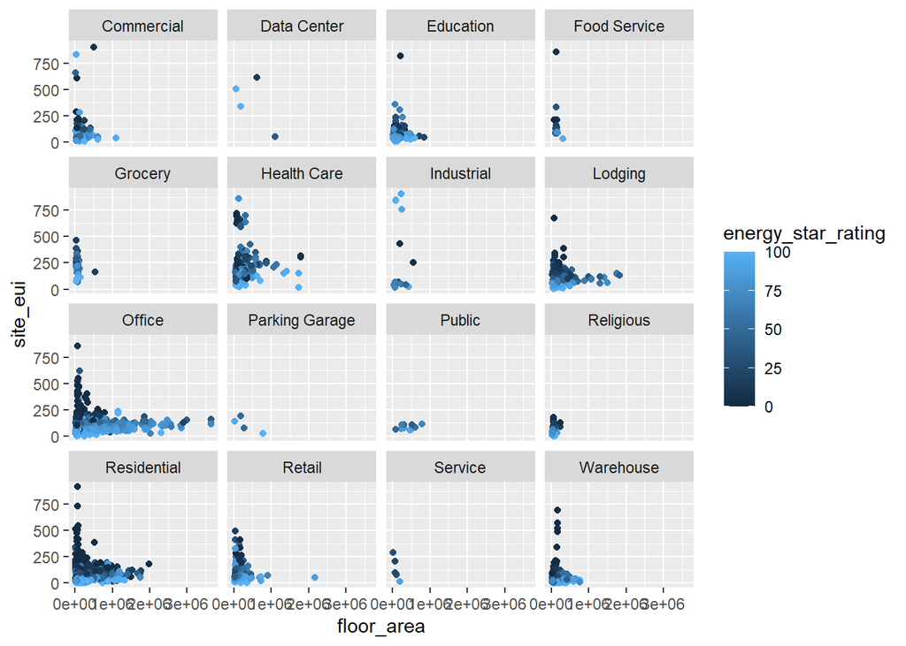

```r
ggplot(train_complete_cases) +
  geom_point(aes(x=floor_area, y=site_eui, color = energy_star_rating)) +
  facet_wrap(~class)
```

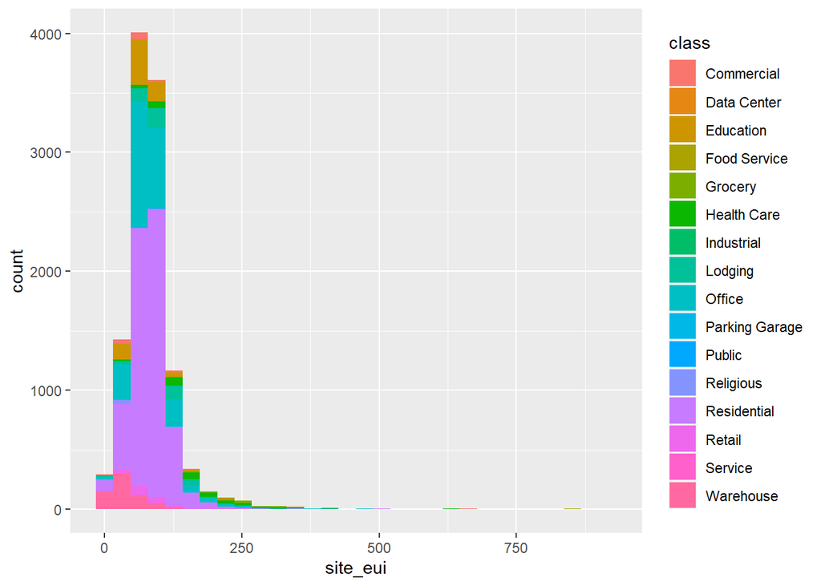

```r
ggplot(train_complete_cases, aes(x=site_eui, fill = class)) +
  geom_histogram()
```

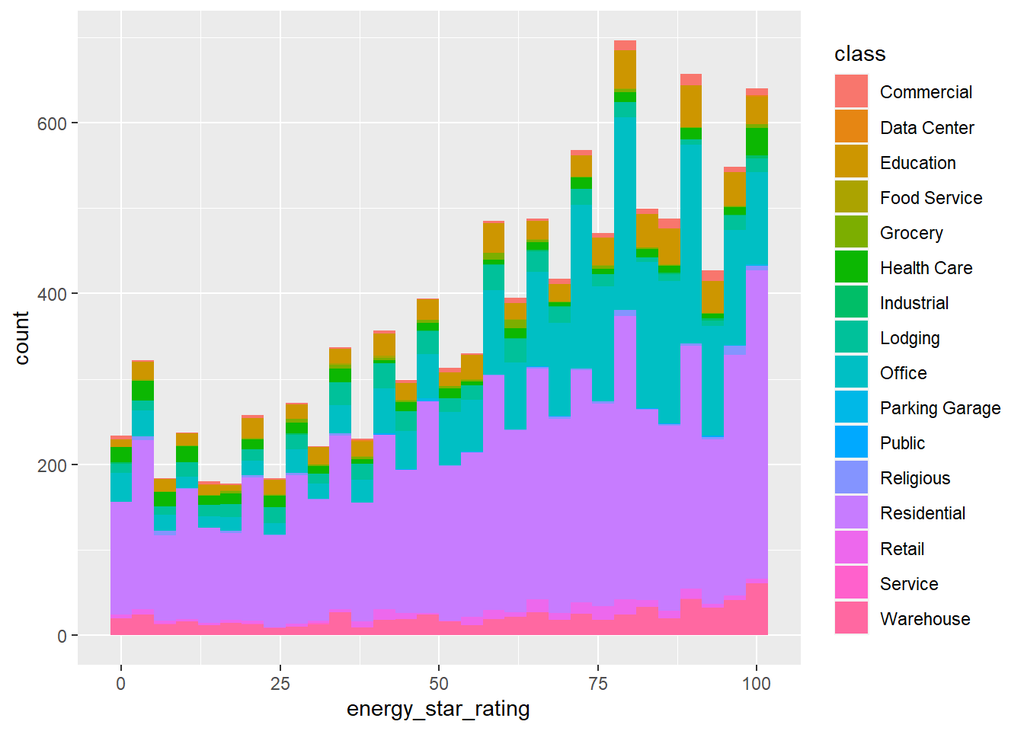

```r
ggplot(train_complete_cases, aes(x=energy_star_rating, fill = class)) +
  geom_histogram()
```

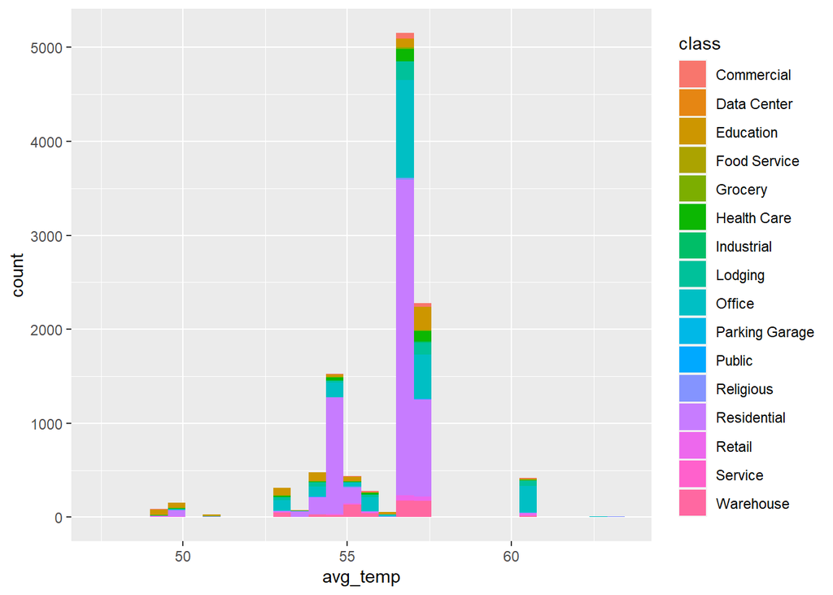

```r
ggplot(train_complete_cases, aes(x=avg_temp, fill = class)) +
  geom_histogram()
```

## Data Analysis

Linear regression (doing it just to do it)

```r
set.seed(1)

### Train data set provided

# na_train_1 <- lm(site_eui ~ year_built + floor_area + cooling_degree_days + heating_degree_days +
#    facility_type + avg_temp, data = train)
# sum_train_1 <- summary(na_train_1)
# sqrt(mean(sum_train_1$residuals^2))
#
# yhat<-na_train_1$fitted.values
# res<-sum_train_1$residuals
# Data<-data.frame(yhat,res)
#
# ggplot(Data, aes(x=yhat,y=res))+
# geom_point()+
# geom_hline(yintercept=0, color="red")+
# labs(x="Fitted y",
# y="Residuals",
# title="Residual Plot")

na_train_2 <- lm(site_eui ~ Year_Factor + floor_area + year_built + energy_star_rating, data = train)
sum_train_2 <-summary(na_train_2)
sqrt(mean(sum_train_2$residuals^2))
```

```
## [1] 45.47597
```

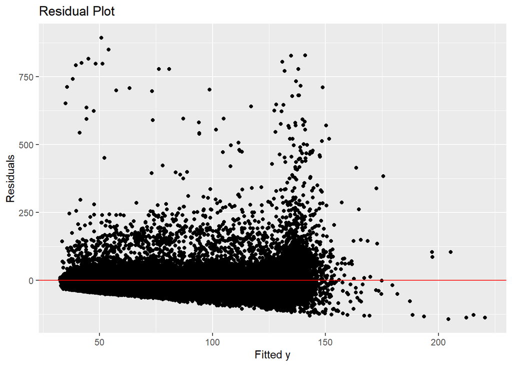

```r
yhat<-na_train_2$fitted.values
res<-sum_train_2$residuals
Data<-data.frame(yhat,res)

ggplot(Data, aes(x=yhat,y=res))+
geom_point()+
geom_hline(yintercept=0, color="red")+
labs(x="Fitted y",
y="Residuals",
title="Residual Plot")
```

```r
# na_train_3 <- lm(site_eui ~ Year_Factor + floor_area + year_built + energy_star_rating + avg_temp + heating_degree_days + march_avg_temp + june_avg_temp + august_avg_temp +
# november_avg_temp + december_avg_temp, data = train)
# sum_train_3 <-summary(na_train_3)
# sqrt(mean(sum_train_3$residuals^2))
#
# yhat<-na_train_3$fitted.values
# res<-sum_train_3$residuals
# Data<-data.frame(yhat,res)
#
# ggplot(Data, aes(x=yhat,y=res))+
# geom_point()+
# geom_hline(yintercept=0, color="red")+
# labs(x="Fitted y",
# y="Residuals",
# title="Residual Plot")

### Complete cases of train data set

# comp_train_1 <- lm(site_eui ~ year_built + floor_area + cooling_degree_days + heating_degree_days +
#    facility_type + avg_temp, data = train_complete_cases)
# sum_train_1_comp <- summary(comp_train_1)
# sqrt(mean(sum_train_1_comp$residuals^2))
#
# yhat<-comp_train_1$fitted.values
# res<-sum_train_1_comp$residuals
# Data<-data.frame(yhat,res)
#
# ggplot(Data, aes(x=yhat,y=res))+
# geom_point()+
# geom_hline(yintercept=0, color="red")+
# labs(x="Fitted y",
# y="Residuals",
# title="Residual Plot")
#
# comp_train_2 <- lm(site_eui ~ Year_Factor + floor_area + year_built + energy_star_rating, data = train_complete_cases)
# sum_train_2_comp <-summary(comp_train_2)
# sqrt(mean(sum_train_2_comp$residuals^2))
#
# yhat<-comp_train_2$fitted.values
# res<-sum_train_2_comp$residuals
# Data<-data.frame(yhat,res)
#
# ggplot(Data, aes(x=yhat,y=res))+
# geom_point()+
# geom_hline(yintercept=0, color="red")+
# labs(x="Fitted y",
# y="Residuals",
# title="Residual Plot")
#
# comp_train_3 <- lm(site_eui ~ Year_Factor + floor_area + year_built + energy_star_rating + avg_temp + heating_degree_days + march_avg_temp + june_avg_temp + august_avg_temp +
# november_avg_temp + december_avg_temp, data = train_complete_cases)
# sum_train_3_comp <-summary(comp_train_3)
# sqrt(mean(sum_train_3_comp$residuals^2))
#
# yhat<-comp_train_3$fitted.values
# res<-sum_train_3_comp$residuals
# Data<-data.frame(yhat,res)
#
# ggplot(Data, aes(x=yhat,y=res))+
# geom_point()+
# geom_hline(yintercept=0, color="red")+
# labs(x="Fitted y",
# y="Residuals",
# title="Residual Plot")
```

### Random Forest

```r
library(randomForest)
rf <- randomForest(site_eui ~ Year_Factor + floor_area + year_built + energy_star_rating, data = train_complete_cases, mtry = 8, importance = T)
summary(rf)
```

```
##                 Length Class  Mode
## call                5  -none- call
## type                1  -none- character
## predicted       11309  -none- numeric
## mse               500  -none- numeric
## rsq               500  -none- numeric
## oob.times       11309  -none- numeric
## importance          8  -none- numeric
## importanceSD        4  -none- numeric
## localImportance     0  -none- NULL
## proximity           0  -none- NULL
## ntree               1  -none- numeric
## mtry                1  -none- numeric
## forest             11  -none- list
## coefs               0  -none- NULL
## y               11309  -none- numeric
## test                0  -none- NULL
## inbag               0  -none- NULL
## terms               3  terms  call
```

```r
rf
```

```
##
## Call:
##  randomForest(formula = site_eui ~ Year_Factor + floor_area +      year_built + energy_star_rating, data = train_complete_cases,      mtry = 8, importance = T)
##                Type of random forest: regression
##                      Number of trees: 500
## No. of variables tried at each split: 4
##
##           Mean of squared residuals: 2176.703
##                     % Var explained: 37.02
```

```r
test$site_eui <- 0
test$site_eui <- predict(rf, newdata = test)

rf_complete <- tibble(id = test$id, site_eui = test$site_eui)
# plot(rf)
#
# importance(rf)
#
# varImpPlot(rf)
```

### Boosting

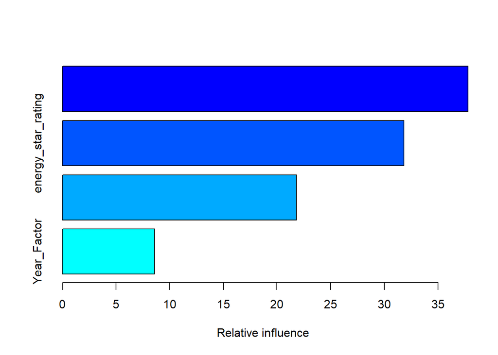

```
##                                   var  rel.inf
## floor_area                 floor_area 37.78399
## energy_star_rating energy_star_rating 31.82395
## year_built                 year_built 21.80113
## Year_Factor               Year_Factor  8.59093
```

```r
library(gbm)
set.seed(12)

gbm <- gbm(site_eui ~ Year_Factor + floor_area + year_built + energy_star_rating, data = train_complete_cases, distribution = 'gaussian', n.trees = 5000, interaction.depth= 4)
summary(gbm)
```

### Gam

```r
gm <- gam(site_eui ~ s(Year_Factor,4) + s(floor_area,4) + s(year_built,4) + s(energy_star_rating,4), data = train)
test$site_eui2 <- predict(gm, newdata = test)

gam_with_nas <- tibble(id = test$id, site_eui = test$site_eui2)
head(gam_with_nas)
```

```
## # A tibble: 6 x 2
##      id site_eui
##   <int>    <dbl>
## 1 75757     83.2
## 2 75758     78.6
## 3 75759    153.
## 4 75760     93.0
## 5 75761     94.7
## 6 75762     99.7
```

```r
gm_comp <- gam(site_eui ~ s(Year_Factor,4) + s(floor_area,4) + s(year_built,4) + s(energy_star_rating,4), data = train_complete_cases)
test$site_eui3 <- predict(gm_comp, newdata = test)

gam_complete <- tibble(id = test$id, site_eui = test$site_eui3)
head(gam_complete)
```

```
## # A tibble: 6 x 2
##      id site_eui
##   <int>    <dbl>
## 1 75757     72.2
## 2 75758     67.6
## 3 75759    148.
## 4 75760     80.1
## 5 75761     80.5
## 6 75762     86.2
```

```r
head(rf_complete)
```

```
## # A tibble: 6 x 2
##      id site_eui
##   <int>    <dbl>
## 1 75757     59.9
## 2 75758     33.2
## 3 75759    193.
## 4 75760     92.6
## 5 75761     93.8
## 6 75762    105.
```